# AEA Formal Privacy Questionnaire Analysis

Authors

Aaron R. Williams

Published

October 19, 2023

```r
options(scipen = 999)

library(tidyverse)
library(qualtRics)
library(urbnthemes)

set_urbn_defaults(style = "print")
```

```r
surveys <- all_surveys()

aea <- fetch_survey(surveyID = surveys$id[1])

aea <- aea %>%
  filter(DistributionChannel != "preview")
```

## 1 Response Quality

Most IP addresses are unique.

```r
aea %>%
  count(IPAddress) %>%
  count(n_frequency = n) %>%
  mutate(prop = (n_frequency * n) / sum(n_frequency * n))
```

| n_frequency | n | prop |
| --- | --- | --- |
| 1 | 971 | 0.944552529 |
| 2 | 22 | 0.042801556 |
| 3 | 3 | 0.008754864 |
| 4 | 1 | 0.003891051 |

```r
aea %>%
  count(LocationLongitude, LocationLatitude) %>%
  count(n_frequency = n) %>%
  mutate(prop = (n_frequency * n) / sum(n_frequency * n))
```

| n_frequency | n | prop |
| --- | --- | --- |
| 1 | 423 | 0.411478599 |
| 2 | 50 | 0.097276265 |
| 3 | 15 | 0.043774319 |
| 4 | 4 | 0.015564202 |
| 5 | 1 | 0.004863813 |
| 6 | 2 | 0.011673152 |
| 8 | 1 | 0.007782101 |
| 419 | 1 | 0.407587549 |

```r
aea %>%
  filter(!is.na(LocationLongitude) & !is.na(LocationLatitude)) %>%
  count(LocationLongitude, LocationLatitude) %>%
  count(n_frequency = n) %>%
  mutate(prop = (n_frequency * n) / sum(n_frequency * n))
```

| n_frequency | n | prop |
| --- | --- | --- |
| 1 | 423 | 0.694581281 |
| 2 | 50 | 0.164203612 |
| 3 | 15 | 0.073891626 |
| 4 | 4 | 0.026272578 |
| 5 | 1 | 0.008210181 |
| 6 | 2 | 0.019704433 |
| 8 | 1 | 0.013136289 |

419 responses have missing longitude and latitude.

### 1.1 Responses by Day

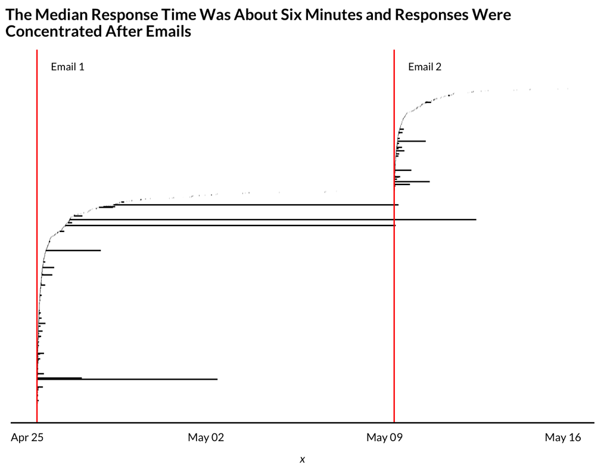

```r
aea %>%
  mutate(id = rank(StartDate)) %>%
  ggplot() +
  geom_linerange(aes(xmin = StartDate, xmax = EndDate, y = id)) +
  geom_vline(
    aes(xintercept = lubridate::ymd_hms("2022-04-25 13:00:00")), color = "red"
  ) +
  geom_vline(
    aes(xintercept = lubridate::ymd_hms("2022-05-09 13:00:00")),
    color = "red"
  ) +
  annotate(
    geom = "text",
    x = lubridate::ymd_hms("2022-04-26 18:00:00"),
    y = 1100,
    label = "Email 1"
  ) +
  annotate(
    geom = "text",
    x = lubridate::ymd_hms("2022-05-10 18:00:00"),
    y = 1100,
    label = "Email 2"
  ) +
  labs(
    title = "The Median Response Time Was About Six Minutes and Responses Were\nConcentrated After Emails",
    y = NULL
  ) +
  remove_axis("y") +
  theme(axis.text.y = element_blank())
```

### 1.2 Distribution of Durations

```r
aea %>%
  mutate(duration = `Duration (in seconds)` / 60) %>%
  summarize(
    mean(duration),
    median(duration)
  )
```

| mean(duration) | median(duration) |
| --- | --- |
| 93.95104 | 6.083333 |

### 1.3 Response Progress

```r
count(aea, Progress)
```

| Progress | n |
| --- | --- |
| 0 | 5 |
| 24 | 128 |
| 36 | 36 |
| 55 | 28 |
| 64 | 207 |
| 91 | 11 |
| 94 | 4 |
| 100 | 609 |

- Most responses were more than 90% complete

## 2 Section 1

### 2.1 Question 1

1.1: Do you reside in the United States?

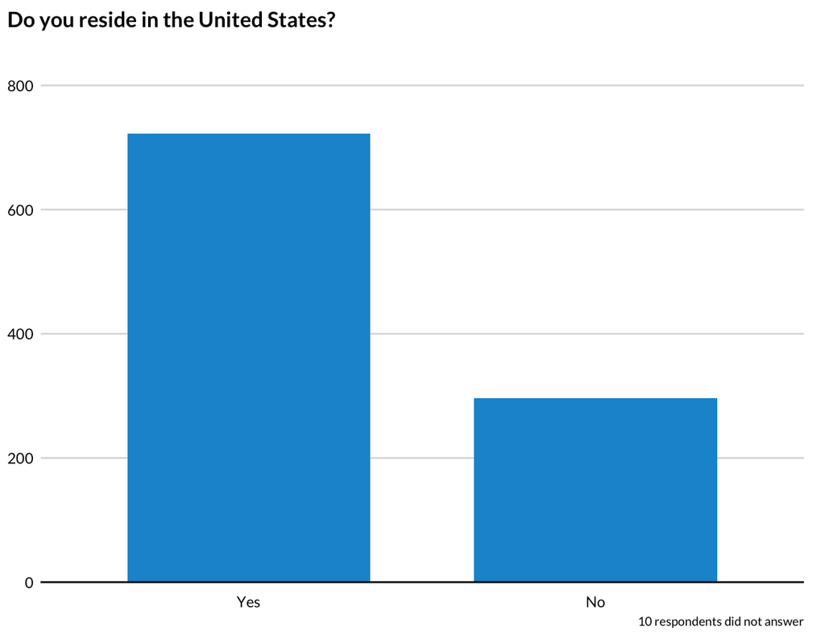

```r
aea %>%
  count(Q1_1) %>%
  mutate(Q1_1 = as.character(Q1_1)) %>%
  filter(!is.na(Q1_1)) %>%
  mutate(Q1_1 = factor(Q1_1, levels = c("Yes", "No"))) %>%
  ggplot(aes(Q1_1, n)) +
  geom_col() +
  scale_y_continuous(expand = expansion(mult = c(0, 0.2))) +
  labs(
    title = "Do you reside in the United States?",
    x = NULL,
    y = NULL,
    caption = "10 respondents did not answer"
  ) +
  remove_ticks()
```

```r
aea %>%
  count(Q1_1) %>%
  mutate(Q1_1 = as.character(Q1_1)) %>%
  filter(!is.na(Q1_1)) %>%
  mutate(prop = n / sum(n))
```

| Q1_1 | n | prop |
| --- | --- | --- |
| Yes | 722 | 0.7092338 |
| No | 296 | 0.2907662 |

1.2: Are you currently a student?

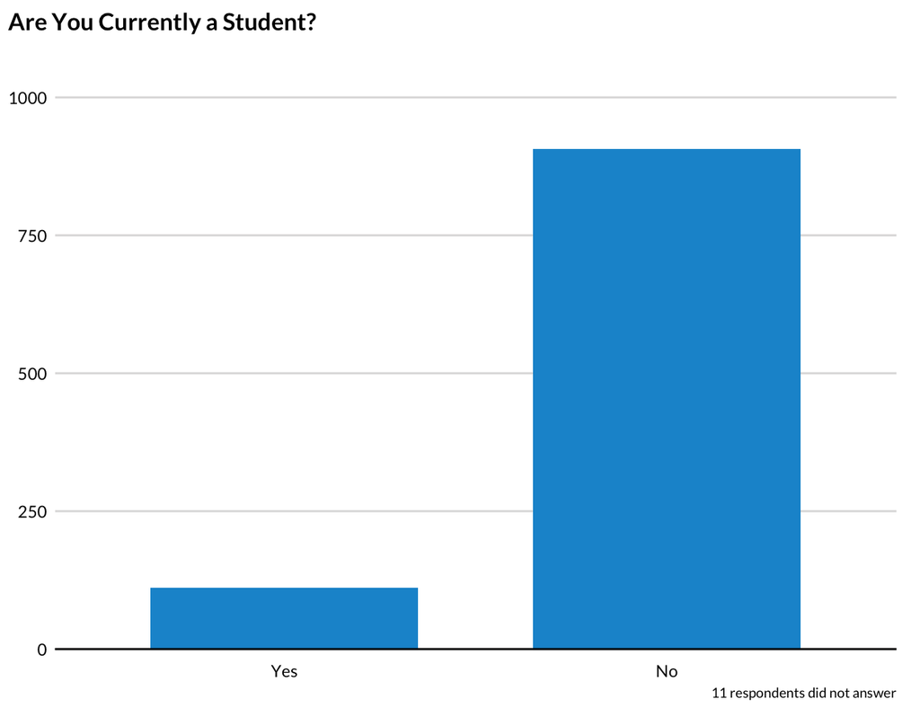

```r
aea %>%
  count(Q1_2) %>%
  mutate(Q1_2 = as.character(Q1_2)) %>%
  filter(!is.na(Q1_2)) %>%
  mutate(Q1_2 = factor(Q1_2, levels = c("Yes", "No"))) %>%
  ggplot(aes(Q1_2, n)) +
  geom_col() +
  scale_y_continuous(expand = expansion(mult = c(0, 0.2))) +
  labs(
    title = "Are You Currently a Student?",
    x = NULL,
    y = NULL,
    caption = "11 respondents did not answer"
  ) +
  remove_ticks()
```

```r
aea %>%
  count(Q1_2) %>%
  mutate(Q1_2 = as.character(Q1_2)) %>%
  filter(!is.na(Q1_2)) %>%
  mutate(prop = n / sum(n))
```

| Q1_2 | n | prop |
| --- | --- | --- |
| Yes | 111 | 0.1091445 |
| No | 906 | 0.8908555 |

1.3: What is the highest degree or level of school you have completed?

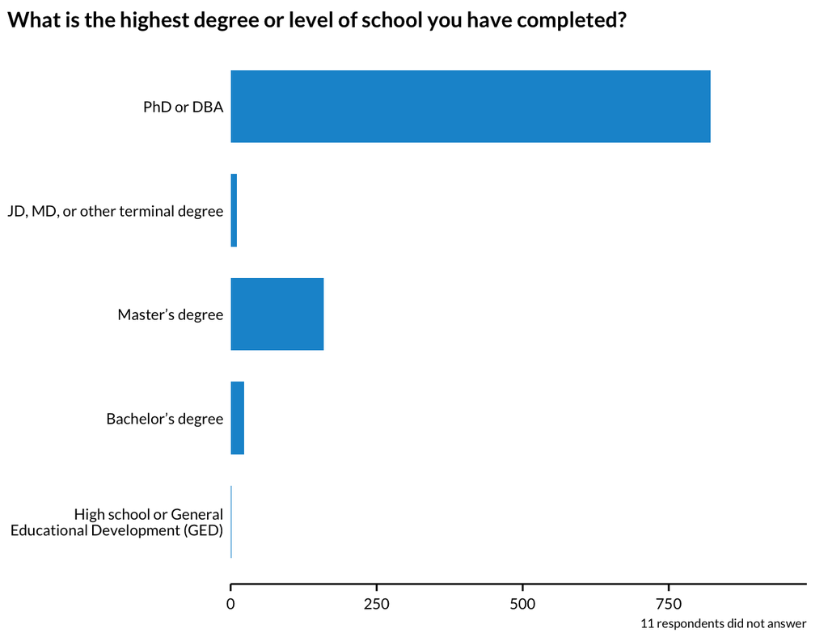

```r
aea %>%
  count(Q1_3) %>%
  slice(1:5) %>%
  mutate(Q1_3 = fct_recode(
    Q1_3,
    `High school or General\nEducational Development (GED)` =
      "High school or General Educational Development (GED)")
  ) %>%
  ggplot(aes(n, Q1_3)) +
  geom_col() +
  scale_x_continuous(expand = expansion(mult = c(0, 0.2))) +
  labs(
    title = "What is the highest degree or level of school you have completed?",
    x = NULL,
    y = NULL,
    caption = "11 respondents did not answer"
  ) +
  theme(panel.grid = element_blank())
```

```r
aea %>%
  count(Q1_3) %>%
  mutate(Q1_3 = as.character(Q1_3)) %>%
  filter(!is.na(Q1_3)) %>%
  mutate(prop = n / sum(n))
```

| Q1_3 | n | prop |
| --- | --- | --- |
| High school or General Educational Development (GED) | 2 | 0.001966568 |
| Bachelor’s degree | 23 | 0.022615536 |
| Master’s degree | 159 | 0.156342183 |
| JD, MD, or other terminal degree | 11 | 0.010816126 |
| PhD or DBA | 822 | 0.808259587 |

1.4: In what year did you finish your highest degree or level of school?

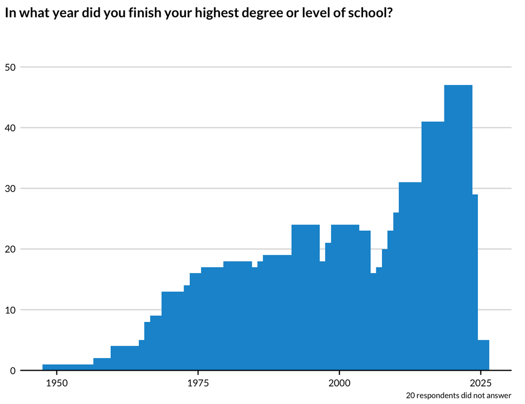

```r
aea %>%
  ggplot(aes(Q1_4)) +
  geom_bar(width = 5) +
  scale_y_continuous(expand = expansion(mult = c(0, 0.2))) +
  labs(
    title = "In what year did you finish your highest degree or level of school?",
    x = NULL,
    y = NULL,
    caption = "20 respondents did not answer"
  )
```

1.5: Which of the following best describes your most recent primary employer?

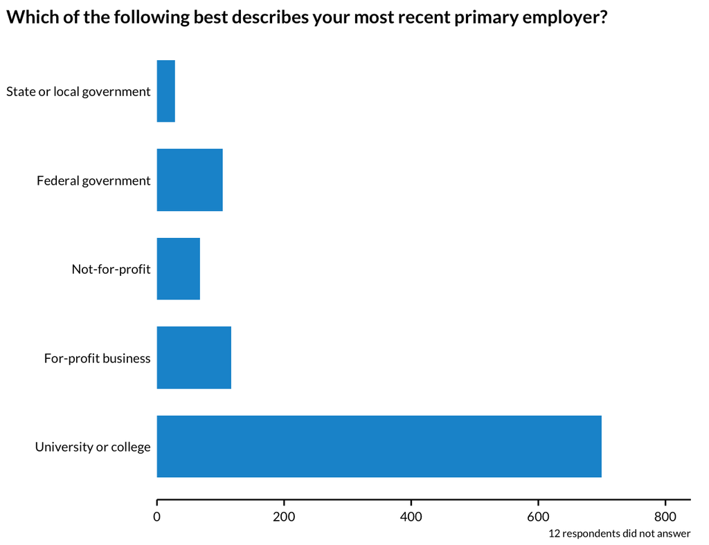

```r
aea %>%
  count(Q1_5) %>%
  slice(1:5) %>%
  ggplot(aes(n, Q1_5)) +
  geom_col() +
  scale_x_continuous(expand = expansion(mult = c(0, 0.2))) +
  labs(
    title = "Which of the following best describes your most recent primary employer?",
    x = NULL,
    y = NULL,
    caption = "12 respondents did not answer"
  ) +
  theme(panel.grid = element_blank())
```

```r
aea %>%
  count(Q1_5) %>%
  mutate(Q1_5 = as.character(Q1_5)) %>%
  filter(!is.na(Q1_5)) %>%
  mutate(prop = n / sum(n))
```

| Q1_5 | n | prop |
| --- | --- | --- |
| University or college | 700 | 0.68897638 |
| For-profit business | 117 | 0.11515748 |
| Not-for-profit | 68 | 0.06692913 |
| Federal government | 103 | 0.10137795 |
| State or local government | 28 | 0.02755906 |

1.6: Have you refereed at least one peer-reviewed journal article in the past five years?

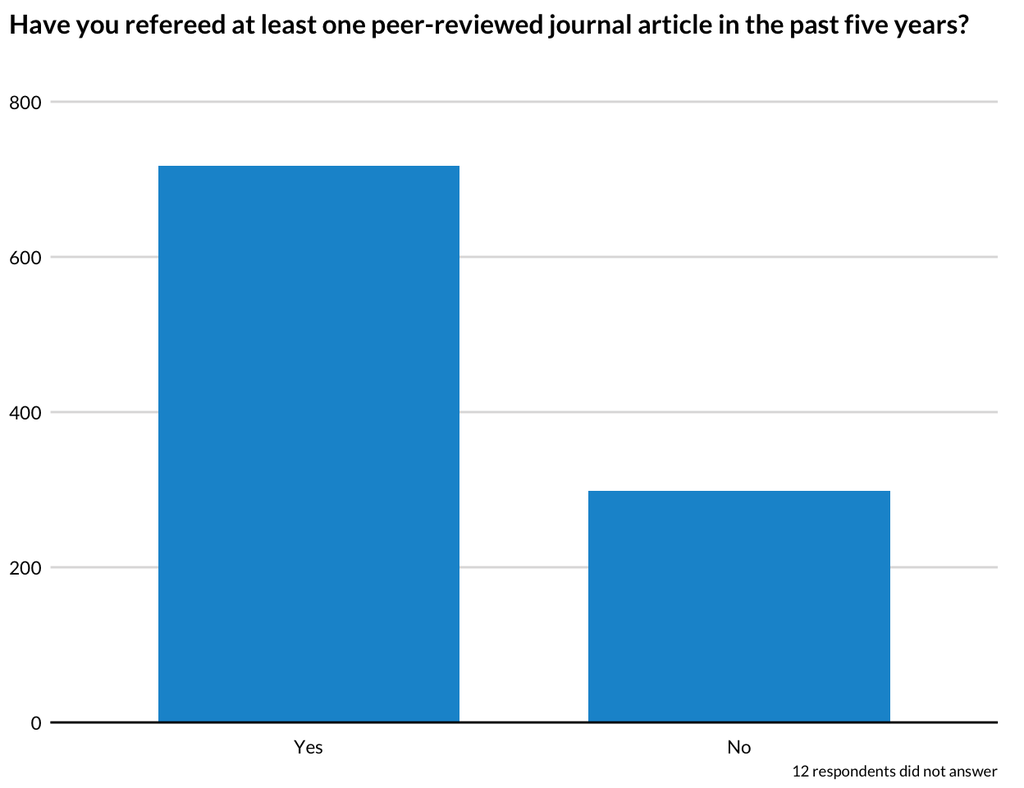

```r
aea %>%
  count(Q1_6) %>%
  slice(1:2) %>%
  ggplot(aes(Q1_6, n)) +
  geom_col() +
  scale_y_continuous(expand = expansion(mult = c(0, 0.2))) +
  labs(
    title = "Have you refereed at least one peer-reviewed journal article in the past five years?",
    x = NULL,
    y = NULL,
    caption = "12 respondents did not answer"
  ) +
  remove_ticks()
```

```r
aea %>%
  count(Q1_6) %>%
  mutate(Q1_6 = as.character(Q1_6)) %>%
  filter(!is.na(Q1_6)) %>%
  mutate(prop = n / sum(n))
```

| Q1_6 | n | prop |
| --- | --- | --- |
| Yes | 717 | 0.7057087 |
| No | 299 | 0.2942913 |

1.7: Select up to three Journal of Economic Literature (JEL) Classification Codes that best describe your area of work:

- Most popular codes
- Patterns in codes

```r
jel <- aea %>%
  select(starts_with("Q1_7"))

top_jel <- jel %>%
  pivot_longer(everything(), names_to = "a", values_to = "JEL code") %>%
  count(`JEL code`) %>%
  filter(!is.na(`JEL code`))
```

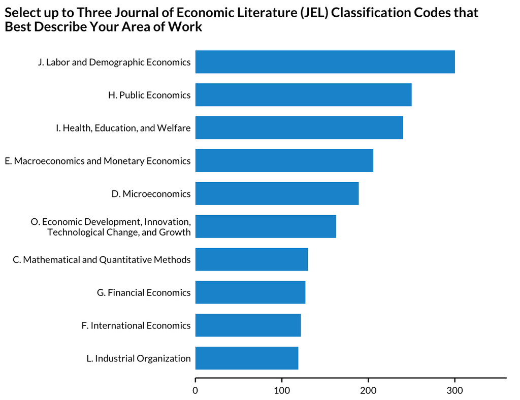

```r
top_jel %>%
  slice_max(n, n = 10) %>%
  mutate(`JEL code` = fct_recode(
    `JEL code`,
    `O. Economic Development, Innovation,\nTechnological Change, and Growth` =
      "O. Economic Development, Innovation, Technological Change, and Growth")
  ) %>%
  mutate(`JEL code` = fct_reorder(`JEL code`, n)) %>%
  ggplot(aes(n, `JEL code`)) +
  geom_col() +
  scale_x_continuous(expand = expansion(mult = c(0, 0.2))) +
  labs(
    title = "Select up to Three Journal of Economic Literature (JEL) Classification Codes that\nBest Describe Your Area of Work",
    x = NULL,
    y = NULL
  ) +
  theme(panel.grid = element_blank())
```

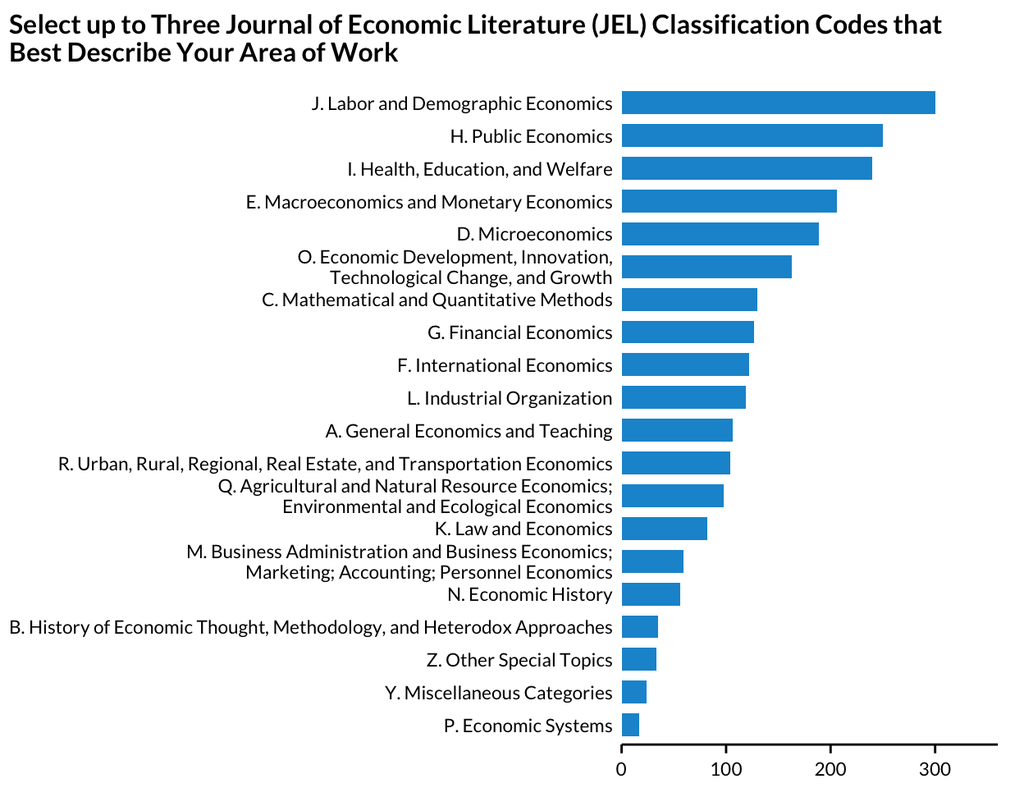

```r
top_jel %>%
  mutate(`JEL code` = fct_recode(
    `JEL code`,
    `M. Business Administration and Business Economics;\nMarketing; Accounting; Personnel Economics` =
      "M. Business Administration and Business Economics; Marketing; Accounting; Personnel Economics",
    `O. Economic Development, Innovation,\nTechnological Change, and Growth` =
      "O. Economic Development, Innovation, Technological Change, and Growth",
    `Q. Agricultural and Natural Resource Economics;\nEnvironmental and Ecological Economics` =
      "Q. Agricultural and Natural Resource Economics; Environmental and Ecological Economics")
  ) %>%
  mutate(`JEL code` = fct_reorder(`JEL code`, n)) %>%
  ggplot(aes(n, `JEL code`)) +
  geom_col() +
  scale_x_continuous(expand = expansion(mult = c(0, 0.2))) +
  labs(
    title = "Select up to Three Journal of Economic Literature (JEL) Classification Codes that\nBest Describe Your Area of Work",
    x = NULL,
    y = NULL
  ) +
  theme(panel.grid = element_blank())
```

## 3 Section 2

### 3.1 Question 1

Q2_1 - 2.1: Please rate the following methods based on how frequently you have used the method on cross-sectional data in the past year:

#### Visualization

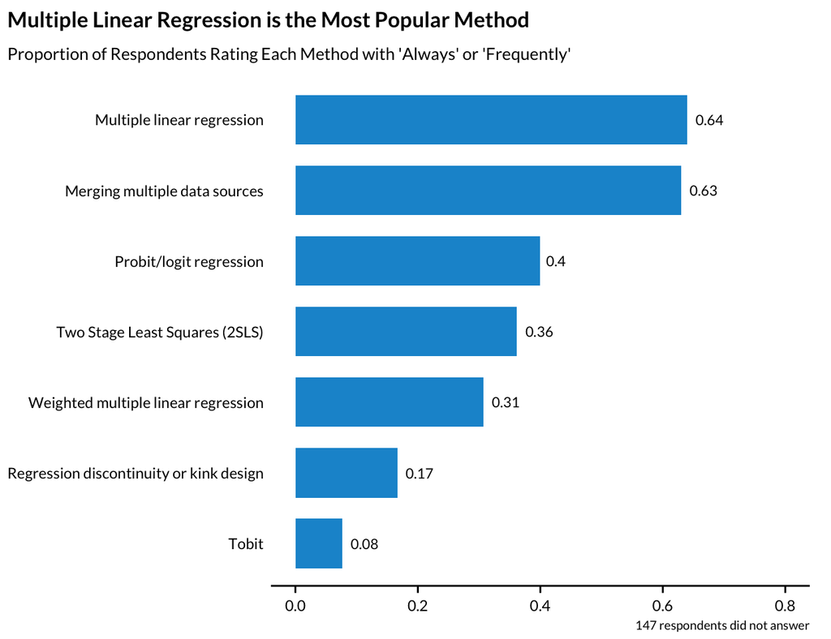

```r
responses <- c("Always", "Frequently")

aea %>%
  summarize(
    `Multiple linear regression` = mean(Q2_1_1 %in% responses, na.rm = TRUE),
    `Weighted multiple linear regression` = mean(Q2_1_2 %in% responses, na.rm = TRUE),
    `Tobit` = mean(Q2_1_3 %in% responses, na.rm = TRUE),
    `Probit/logit regression` = mean(Q2_1_4 %in% responses, na.rm = TRUE),
    `Regression discontinuity or kink design` = mean(Q2_1_5 %in% responses, na.rm = TRUE),
    `Merging multiple data sources` = mean(Q2_1_6 %in% responses, na.rm = TRUE),
    `Two Stage Least Squares (2SLS)` = mean(Q2_1_7 %in% responses, na.rm = TRUE)
  ) %>%
  pivot_longer(
    everything(),
    names_to = "Method",
    values_to = "Proportion 'Always' or 'Frequently'"
  ) %>%
  mutate(Method = fct_reorder(Method, `Proportion 'Always' or 'Frequently'`)) %>%
  ggplot(aes(x = `Proportion 'Always' or 'Frequently'`, y = Method)) +
  geom_col() +
  geom_text(aes(label = round(`Proportion 'Always' or 'Frequently'`, 2), hjust = -0.3)) +
  scale_x_continuous(limits = c(0, 0.8)) +
  labs(
    title = "Multiple Linear Regression is the Most Popular Method",
    subtitle = "Proportion of Respondents Rating Each Method with 'Always' or 'Frequently'",
    x = NULL,
    y = NULL,
    caption = "147 respondents did not answer"
  ) +
  theme(panel.grid = element_blank())
```

#### Table

The number observations missing all Q2.1 variables.

```r
count(aea, missing_all = is.na(Q2_1_1) & is.na(Q2_1_2) & is.na(Q2_1_3) & is.na(Q2_1_4) & is.na(Q2_1_5) & is.na(Q2_1_6) & is.na(Q2_1_7))
```

| missing_all | n |
| --- | --- |
| FALSE | 881 |
| TRUE | 147 |

Multiple linear regression

```r
count(aea, Q2_1_1)
```

| Q2_1_1 | n |
| --- | --- |
| Always | 288 |
| Frequently | 370 |
| Infrequently | 117 |
| Never | 93 |
| NA | 160 |

Weighted multiple linear regression

```r
count(aea, Q2_1_2)
```

| Q2_1_2 | n |
| --- | --- |
| Always | 75 |
| Frequently | 241 |
| Infrequently | 279 |
| Never | 260 |
| NA | 173 |

Tobit

```r
count(aea, Q2_1_3)
```

| Q2_1_3 | n |
| --- | --- |
| Always | 12 |
| Frequently | 67 |
| Infrequently | 288 |
| Never | 456 |
| NA | 205 |

Probit/logit regression

```r
count(aea, Q2_1_4)
```

| Q2_1_4 | n |
| --- | --- |
| Always | 72 |
| Frequently | 339 |
| Infrequently | 264 |
| Never | 182 |
| NA | 171 |

Regression discontinuity or kink design

```r
count(aea, Q2_1_5)
```

| Q2_1_5 | n |
| --- | --- |
| Always | 20 |
| Frequently | 151 |
| Infrequently | 292 |
| Never | 388 |
| NA | 177 |

Merging multiple data sources

```r
count(aea, Q2_1_6)
```

| Q2_1_6 | n |
| --- | --- |
| Always | 309 |
| Frequently | 339 |
| Infrequently | 99 |
| Never | 117 |
| NA | 164 |

Two Stage Least Squares (2SLS)

```r
count(aea, Q2_1_7)
```

| Q2_1_7 | n |
| --- | --- |
| Always | 46 |
| Frequently | 326 |
| Infrequently | 262 |
| Never | 229 |
| NA | 165 |

### 3.2 Question 2

See analysis/02_analysis-text.qmd.

### 3.3 Question 3

2.3: Please rate the following information obtained from multiple linear regression based on its importance for your work:

#### Visualization

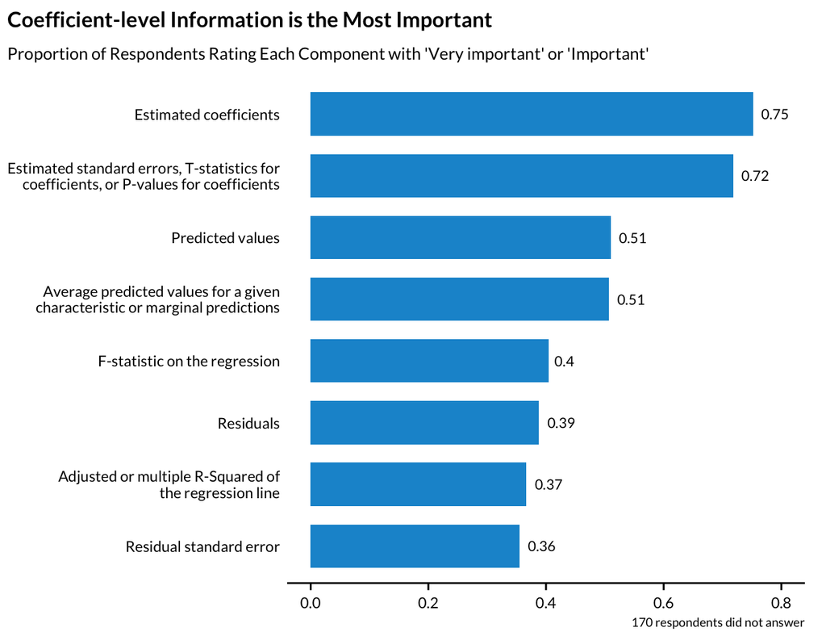

```r
responses <- c("Very important", "Important")

aea %>%
  summarize(
    `Estimated coefficients` = mean(Q2_3_1 %in% responses, na.rm = TRUE),
    `Estimated standard errors, T-statistics for\ncoefficients, or P-values for coefficients` = mean(Q2_3_2 %in% responses, na.rm = TRUE),
    `Adjusted or multiple R-Squared of\nthe regression line` = mean(Q2_3_3 %in% responses, na.rm = TRUE),
    `F-statistic on the regression` = mean(Q2_3_4 %in% responses, na.rm = TRUE),
    `Residuals` = mean(Q2_3_5 %in% responses, na.rm = TRUE),
    `Residual standard error` = mean(Q2_3_6 %in% responses, na.rm = TRUE),
    `Predicted values` = mean(Q2_3_7 %in% responses, na.rm = TRUE),
    `Average predicted values for a given\ncharacteristic or marginal predictions` = mean(Q2_3_8 %in% responses, na.rm = TRUE)
  ) %>%
  pivot_longer(
    everything(),
    names_to = "Method",
    values_to = "Proportion 'Very important' or 'Important'"
  ) %>%
  mutate(Method = fct_reorder(Method, `Proportion 'Very important' or 'Important'`)) %>%
  ggplot(aes(x = `Proportion 'Very important' or 'Important'`, y = Method)) +
  geom_col() +
  geom_text(aes(label = round(`Proportion 'Very important' or 'Important'`, 2), hjust = -0.3)) +
  scale_x_continuous(limits = c(0, 0.8)) +
  labs(
    title = "Coefficient-level Information is the Most Important",
    subtitle = "Proportion of Respondents Rating Each Component with 'Very important' or 'Important'",
    x = NULL,
    y = NULL,
    caption = "170 respondents did not answer"
  ) +
  theme(panel.grid = element_blank())
```

#### Table

The number observations missing all Q2.3 variables.

```r
count(aea, missing_all = is.na(Q2_3_1) & is.na(Q2_3_2) & is.na(Q2_3_3) & is.na(Q2_3_4) & is.na(Q2_3_5) & is.na(Q2_3_6) & is.na(Q2_3_7) & is.na(Q2_3_8))
```

| missing_all | n |
| --- | --- |
| FALSE | 858 |
| TRUE | 170 |

Estimated coefficients

```r
count(aea, Q2_3_1)
```

| Q2_3_1 | n |
| --- | --- |
| Important | 254 |
| Not at all important | 31 |
| Somewhat important | 47 |
| Very important | 519 |
| NA | 177 |

Estimated standard errors, T-statistics for coefficients, or P-values for coefficients

```r
count(aea, Q2_3_2)
```

| Q2_3_2 | n |
| --- | --- |
| Important | 252 |
| Not at all important | 36 |
| Somewhat important | 77 |
| Very important | 486 |
| NA | 177 |

Adjusted or multiple R-Squared of the regression line

```r
count(aea, Q2_3_3)
```

| Q2_3_3 | n |
| --- | --- |
| Important | 255 |
| Not at all important | 123 |
| Somewhat important | 340 |
| Very important | 122 |
| NA | 188 |

F-statistic on the regression

```r
count(aea, Q2_3_4)
```

| Q2_3_4 | n |
| --- | --- |
| Important | 290 |
| Not at all important | 139 |
| Somewhat important | 280 |
| Very important | 126 |
| NA | 193 |

Residuals

```r
count(aea, Q2_3_5)
```

| Q2_3_5 | n |
| --- | --- |
| Important | 275 |
| Not at all important | 94 |
| Somewhat important | 329 |
| Very important | 124 |
| NA | 206 |

Residual standard error

```r
count(aea, Q2_3_6)
```

| Q2_3_6 | n |
| --- | --- |
| Important | 249 |
| Not at all important | 140 |
| Somewhat important | 319 |
| Very important | 116 |
| NA | 204 |

Predicted values

```r
count(aea, Q2_3_7)
```

| Q2_3_7 | n |
| --- | --- |
| Important | 339 |
| Not at all important | 69 |
| Somewhat important | 244 |
| Very important | 185 |
| NA | 191 |

Average predicted values for a given characteristic or marginal predictions

```r
count(aea, Q2_3_8)
```

| Q2_3_8 | n |
| --- | --- |
| Important | 317 |
| Not at all important | 90 |
| Somewhat important | 226 |
| Very important | 204 |
| NA | 191 |

### 3.4 Question 5

See analysis/02_analysis-text.qmd.

## 4 Section 3

### 4.1 Question 1

Q3_1 - 3.1: Please rate your familiarity with the concept of differential privacy.

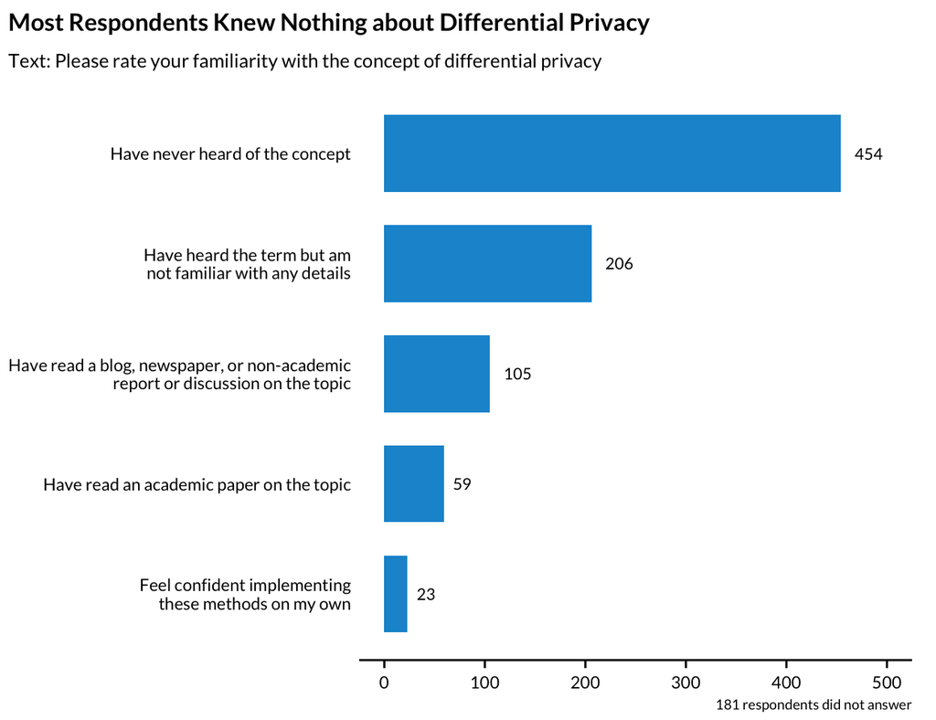

```r
aea %>%
  count(Q3_1) %>%
  filter(n != 181) %>%
  mutate(Q3_1 = fct_recode(
    Q3_1,
    `Have heard the term but am\nnot familiar with any details` =
      "Have heard the term but am not familiar with any details",
    `Have read a blog, newspaper, or non-academic\nreport or discussion on the topic` =
      "Have read a blog, newspaper, or non-academic report or discussion on the topic",
    `Feel confident implementing\nthese methods on my own` =
      "Feel confident implementing these methods on my own")
  ) %>%
  mutate(Q3_1 = fct_rev(Q3_1)) %>%
  ggplot(aes(n, Q3_1)) +
  geom_col() +
  geom_text(aes(label = n, hjust = -0.5)) +
  scale_x_continuous(limits = c(NA, 500)) +
  labs(
    title = "Most Respondents Knew Nothing about Differential Privacy",
    subtitle = "Text: Please rate your familiarity with the concept of differential privacy",
    x = NULL,
    y = NULL,
    caption = "181 respondents did not answer"
  ) +
  theme(panel.grid = element_blank())
```

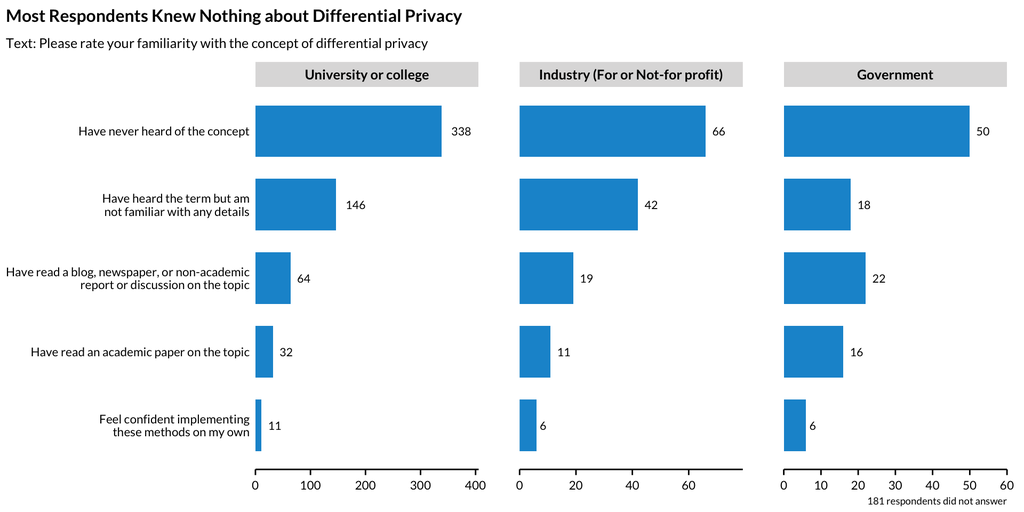

```r
aea %>%
    mutate(
    Q1_5 = fct_recode(
      Q1_5,
      `Industry (For or Not-for profit)` = "For-profit business",
      `Industry (For or Not-for profit)` = "Not-for-profit",
      `Government` = "Federal government",
      `Government` = "State or local government"
    )
  ) %>%
  count(Q3_1, Q1_5) %>%
  filter(
    !is.na(as.character(Q3_1)),
    !is.na(as.character(Q1_5))
  ) %>%
  mutate(Q3_1 = fct_recode(
    Q3_1,
    `Have heard the term but am\nnot familiar with any details` =
      "Have heard the term but am not familiar with any details",
    `Have read a blog, newspaper, or non-academic\nreport or discussion on the topic` =
      "Have read a blog, newspaper, or non-academic report or discussion on the topic",
    `Feel confident implementing\nthese methods on my own` =
      "Feel confident implementing these methods on my own")
  ) %>%
  mutate(Q3_1 = fct_rev(Q3_1)) %>%
  ggplot(aes(n, Q3_1)) +
  geom_col() +
  geom_text(aes(label = n, hjust = -0.5)) +
  scale_x_continuous(expand = expansion(mult = c(0, 0.2))) +
  facet_wrap(~Q1_5, scales = "free_x") +
  labs(
    title = "Most Respondents Knew Nothing about Differential Privacy",
    subtitle = "Text: Please rate your familiarity with the concept of differential privacy",
    x = NULL,
    y = NULL,
    caption = "181 respondents did not answer"
  ) +
  theme(
    panel.grid = element_blank(),
    panel.spacing = unit(2, "lines")
  )
```

Calculate proportion with no familiarity with DP.

```r
(454 + 206) / (454 + 206 + 105 + 59 + 23)
```

```
[1] 0.7792208
```

### 4.2 Question 2

Q3_2 - 3.2: Please rate your familiarity with the concept of formal privacy

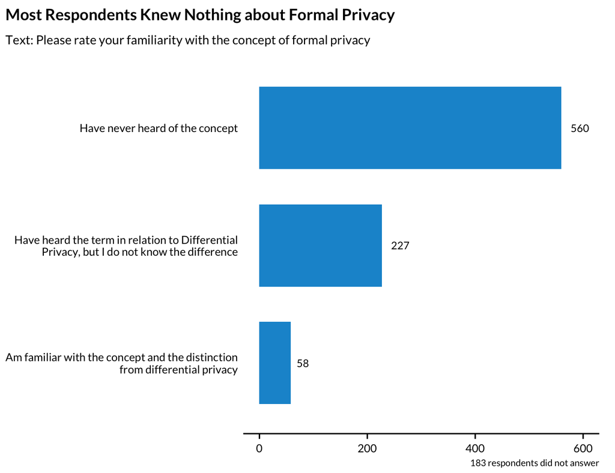

```r
aea %>%
  count(Q3_2) %>%
  filter(n != 183) %>%
  mutate(Q3_2 = fct_recode(
    Q3_2,
    `Have heard the term in relation to Differential\nPrivacy, but I do not know the difference` =
      "Have heard the term in relation to Differential Privacy, but I do not know the difference",
    `Am familiar with the concept and the distinction\nfrom differential privacy` =
      "Am familiar with the concept and the distinction from differential privacy")
  ) %>%
  mutate(Q3_2 = fct_rev(Q3_2)) %>%
  ggplot(aes(n, Q3_2)) +
  geom_col() +
  geom_text(aes(label = n, hjust = -0.5)) +
  scale_x_continuous(limits = c(NA, 600)) +
  labs(
    title = "Most Respondents Knew Nothing about Formal Privacy",
    subtitle = "Text: Please rate your familiarity with the concept of formal privacy",
    x = NULL,
    y = NULL,
    caption = "183 respondents did not answer"
  ) +
  theme(panel.grid = element_blank())
```

Calculate the proportion with no or little experience.

```r
aea %>%
  count(Q3_2)
```

| Q3_2 | n |
| --- | --- |
| Have never heard of the concept | 560 |
| Have heard the term in relation to Differential Privacy, but I do not know the difference | 227 |
| Am familiar with the concept and the distinction from differential privacy | 58 |
| NA | 183 |

```r
(560 + 227) / (560 + 227 + 58)
```

```
[1] 0.9313609
```

### 4.3 Question 3

Q3_3 - 3.3: What share of economists you know in your professional circles have discussed the US Census Bureau’s adoption of differential privacy/formal privacy for the 2020 Census?

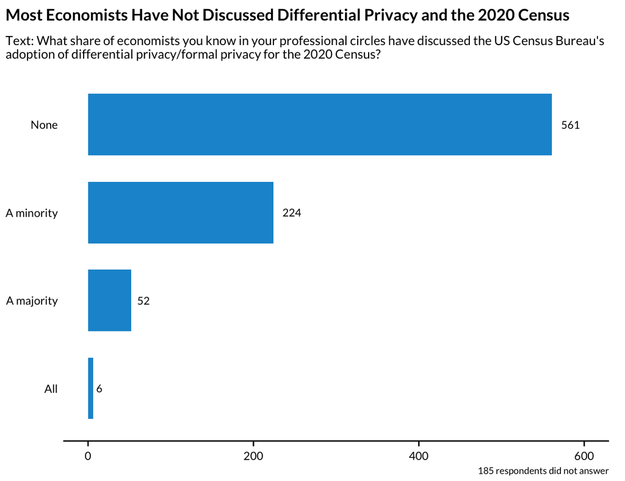

```r
aea %>%
  count(Q3_3) %>%
  filter(n != 185) %>%
  mutate(Q3_3 = fct_rev(Q3_3)) %>%
  ggplot(aes(n, Q3_3)) +
  geom_col() +
  geom_text(aes(label = n, hjust = -0.5)) +
  scale_x_continuous(limits = c(NA, 600)) +
  labs(
    title = "Most Economists Have Not Discussed Differential Privacy and the 2020 Census",
    subtitle = "Text: What share of economists you know in your professional circles have discussed the US Census Bureau's\nadoption of differential privacy/formal privacy for the 2020 Census?",
    x = NULL,
    y = NULL,
    caption = "185 respondents did not answer"
  ) +
  theme(panel.grid = element_blank())
```

### 4.4 Question 4

Q3_4 - 3.4: What share of economists you know in your professional circles work with differential privacy/formal privacy methods?

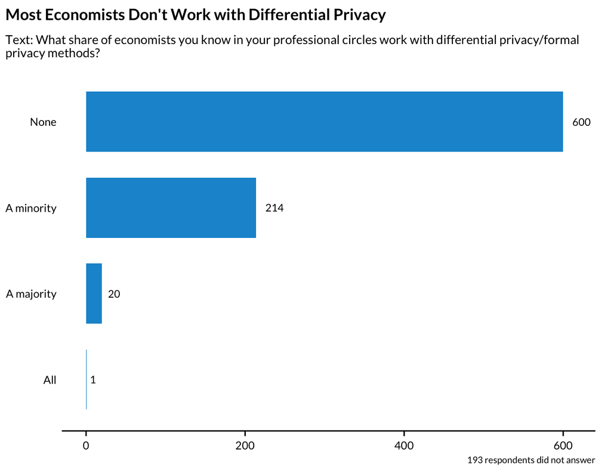

```r
aea %>%
  count(Q3_4) %>%
  filter(n != 193) %>%
  mutate(Q3_4 = fct_rev(Q3_4)) %>%
  ggplot(aes(n, Q3_4)) +
  geom_col() +
  geom_text(aes(label = n, hjust = -0.5)) +
  scale_x_continuous(limits = c(NA, 610)) +
  labs(
    title = "Most Economists Don't Work with Differential Privacy",
    subtitle = "Text: What share of economists you know in your professional circles work with differential privacy/formal\nprivacy methods?",
    x = NULL,
    y = NULL,
    caption = "193 respondents did not answer"
  ) +
  theme(panel.grid = element_blank())
```